Back to home page

# Airbnb Market Analysis - Part I

The idea of this notebook is to give you some insights of airbnb San Francisco market as well as the factors that can affect a host's revenue. **Part I** will mainly focus on the price part.

`monthly income of a host = price * monthly occupancy`

[Inside Airbnb](http://insideairbnb.com/get-the-data.html) dataset include:

- listings.csv
- calendar.csv
- reviews.csv

**listings.csv** consists of details of all the listings including their price, accomodates, ratings, number of reviews, summary, name, owner name, Description, host Id and many other columns decribing details of listings.

**calendar.csv** consists of details of listings and its availability and its price.

**reviews.csv** consits of reveiws for each listing.

## Load data

```python
import pandas as pd
import numpy as np
import function as F
import matplotlib.pyplot as plt
import seaborn as sns
import json
%config InlineBackend.figure_format = 'retina'
%matplotlib inline
plt.style.use('ggplot')
```

```python
columns = ['id','price','availability_30','availability_60','reviews_per_month',
'number_of_reviews','last_review','host_since','minimum_nights',
'room_type','host_response_time', 'host_is_superhost',
'review_scores_rating','property_type', 'guests_included',
'neighbourhood_cleansed','bedrooms', 'zipcode',
'calculated_host_listings_count','host_identity_verified',
'cleaning_fee','last_scraped','latitude','longitude','beds',
'cancellation_policy','access','description','notes','transit',
'instant_bookable','extra_people','maximum_nights','house_rules',
]
listings = pd.read_csv('data/nearest/listings20180705.csv', usecols=columns)
```

```python
# some cleanning work
listings.loc[listings.bedrooms==0,'bedrooms']=1 # convert all 0 bedroom to 1
listings.bedrooms.fillna(1, inplace=True)
listings['price'] = listings.price.str.replace(r'[$,]','').astype(float) # strip the dollar sign
mask = (((listings.price>=1000)&(listings.bedrooms==1))|(listings.price>=5000)) #Remove abnormal price data
listings = listings[~mask]
```

```python
listings.head(1)
```

|  | id | last_scraped | description | notes | transit | access | house_rules | host_since | host_response_time | host_is_superhost | ... | maximum_nights | availability_30 | availability_60 | number_of_reviews | last_review | review_scores_rating | instant_bookable | cancellation_policy | calculated_host_listings_count | reviews_per_month |
| --- | --- | --- | --- | --- | --- | --- | --- | --- | --- | --- | --- | --- | --- | --- | --- | --- | --- | --- | --- | --- | --- |
| 0 | 958 | 2018-07-05 | Our bright garden unit overlooks a grassy back... | Due to the fact that we have children and a do... | *Public Transportation is 1/2 block away. *Ce... | *Full access to patio and backyard (shared wit... | * No Pets - even visiting guests for a short t... | 2008-07-31 | within an hour | t | ... | 30 | 3 | 6 | 143 | 2018-06-20 | 97.0 | f | moderate | 1 | 1.31 |

1 rows × 34 columns

```python
listings.shape
```

```
(4693, 34)
```

In the first part, I will use the lastest scrape of 2018-07-05, which consists of 4693 listings from airbnb website. This dataset can be seen as a snapshot of the airbnb SF market volumn of that day.

## Where are these listings located?

[figure not shown]

As the maps above show, Airbnb units appear to be concentrated in the northern and eastern neighborhoods of the city.

## Room type

Airbnb hosts can list entire homes/apartments, private or shared rooms.

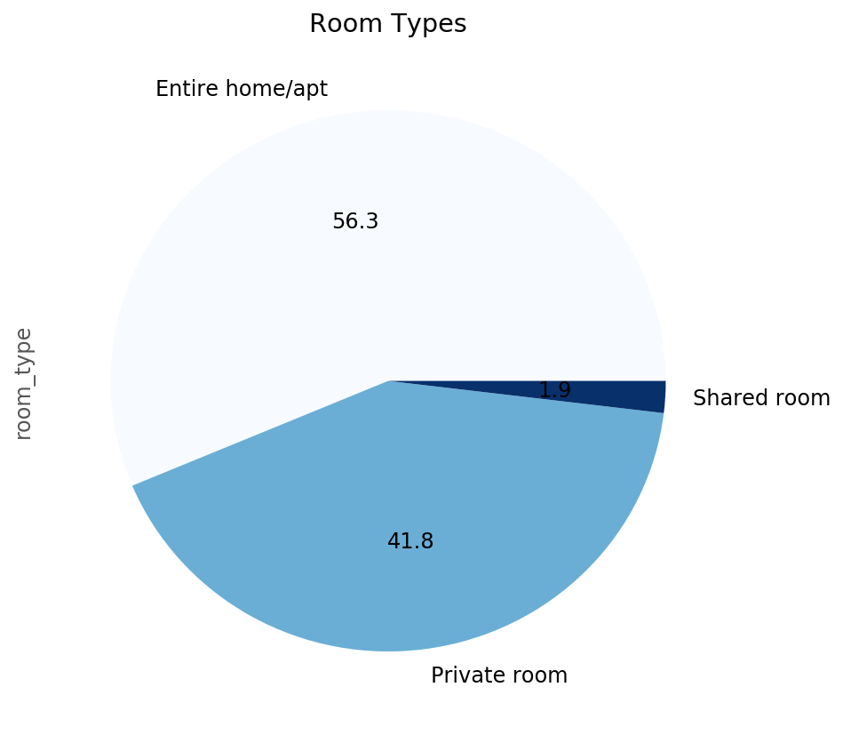

```python
types = listings.room_type.value_counts()
types.plot.pie(y = 'room_type', colormap = 'Blues', figsize=(7,7),
               fontsize = 12, autopct = '%.1f',
               title = 'Room Types');
```

```python
pd.DataFrame(types)
```

|  | room_type |
| --- | --- |
| Entire home/apt | 2641 |
| Private room | 1962 |
| Shared room | 90 |

Most of the listings are entire home or private room.

## Property type

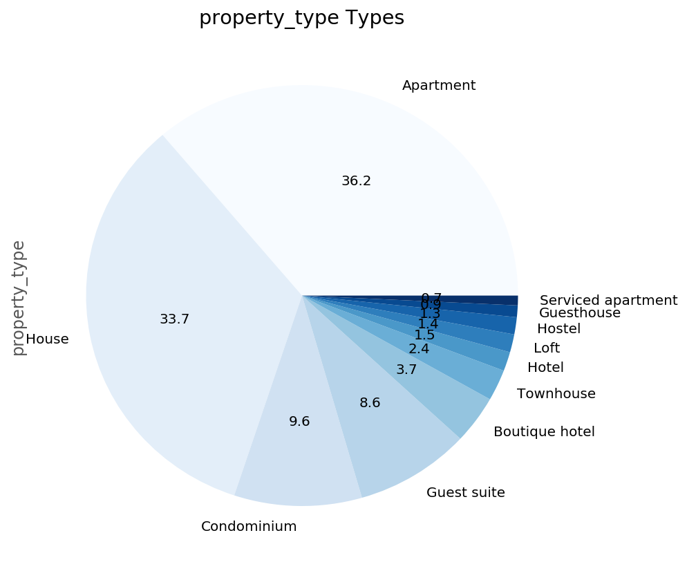

```python
types = listings.property_type.value_counts()
types = types[types > 30]
types.plot.pie(colormap = 'Blues', figsize=(7,7),
               fontsize = 10, autopct = '%.1f',
               title = 'property_type Types');
```

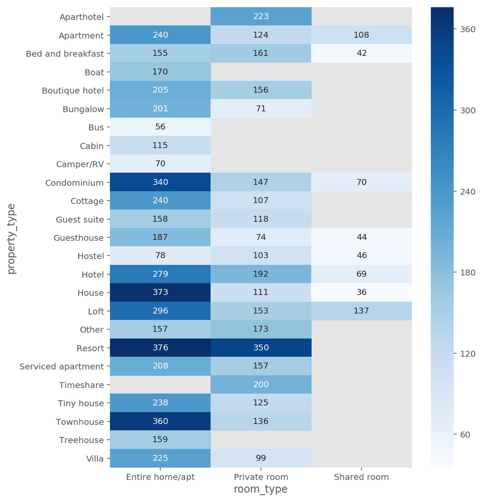

```python
plt.figure(figsize=(8,10))
sns.heatmap(listings.groupby([
        'property_type', 'room_type']).price.mean().unstack(),
            annot=True, fmt=".0f", cmap='Blues');
```

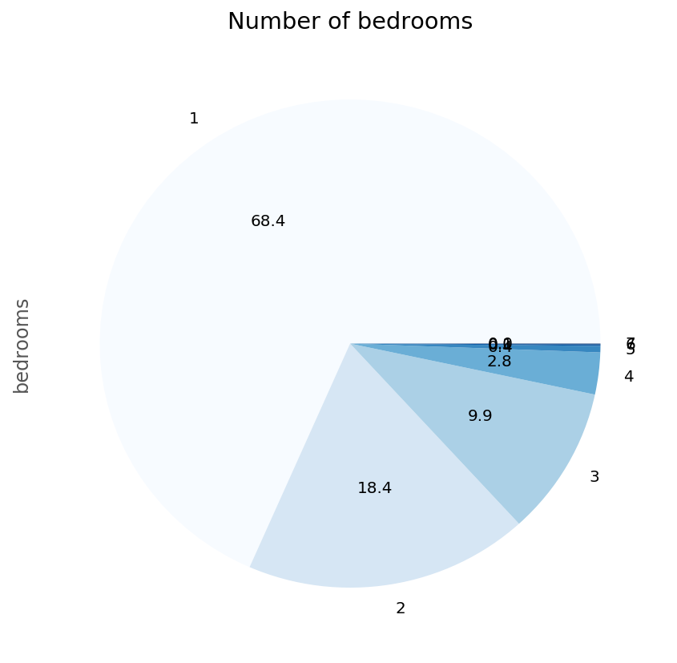

```python
bedroom = listings.bedrooms.value_counts()
bedroom.plot.pie(colormap = 'Blues', figsize=(7,7),
               fontsize = 10, autopct = '%.1f',
               title = 'Number of bedrooms');
```

## Neighborhood

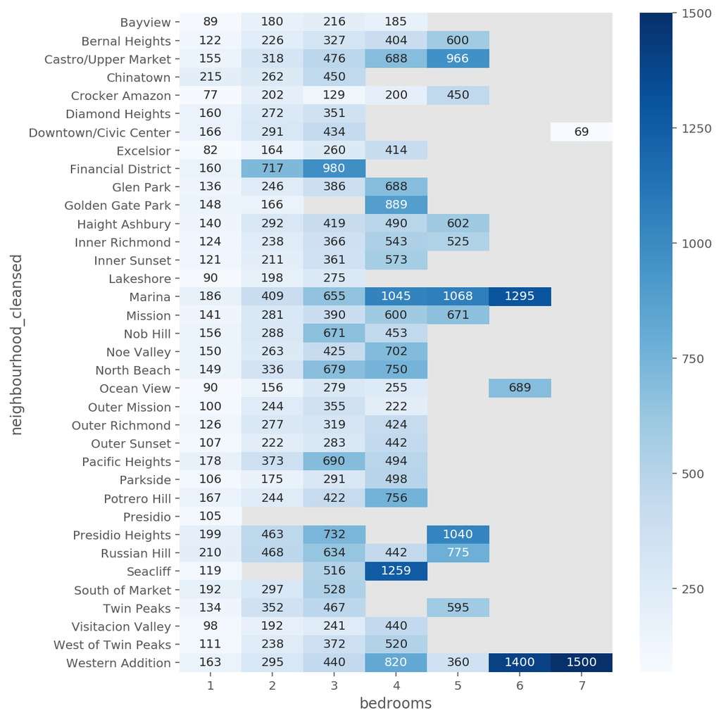

```python
plt.figure(figsize=(8,10))
sns.heatmap(listings.groupby([
        'neighbourhood_cleansed', 'bedrooms']).price.mean().unstack(),annot=True,
            fmt=".0f", cmap='Blues');
```

As for my webapp, new users do not necessarily know how to set the short term rate, what price per day is considered as 'fair price'. To solve this problem, I used a Knn(n=5) model to take the price from the market (2018-7-5).

- First, based on users' address, I sent a request to Googlemap about the latitude and longitude of the address as well as the zip-code.
- Second, based on users' number of bedroom, room_type(entire home/private room/shared room), property_type(house, apartment, others) and zipcode, I can quickly narrow down the search zone with a smaller dataframe. Then I used the knn model to find the price of geographically the 5 closest neighbors using lat and lon.
- Third, I average my neighbours' price, which is my guideline price to predict the occupancy for the next stage.(see part 2)